# Credit Card Approval Prediction

### 6.Classification Models

##### 6.1 Logistic Regression

Logistic Regression is a special case of one of the generalized linear models (GLM). Logistic Regression is parametric and it predicts the probability of an outcome variable being 0 or 1. The probability (p) is linked to a linear function of the predictors using the Log of the odds (Log(p/1-p)) or the logit function. The logit function maps the output from [-inf, inf] to [0,1] which is then transformed to class 1 if p > 0.5 and 0 otherwise. Parameters (theta) for the predictors are estimated using maximum likelihood (MLE), with the p= 1/1+exp(-thetaTx). The values are assumed linear in the logit space, and nonlinear (sigmoid) on the natural scale. Logistic regression does not make any assumptions over the distribution of the classes. However, when classes are well separated, the parameter estimates can be unstable. Further adding regularization to the optimization can shrink parameters (in Ridge/Lasso) and zero some (in Lasso) to avoid overfitting to the training data and manage the variance. This shrinkage (controlled by alpha and lambda) is optimized using CV to tradeoff bias-variance. For Logistic Regression, we have used the Smote upsampled data, with a Log function applied to the continuous variables to manage skewness. Also scaling and centering is done as part of the modeling. We have implemented Bagging to glmnet function, with the possibility of setting the sample fraction, replacement strategy for the bootstrap. The prediction is made via majority voting.

```r
#Model.Matrix
X_Train_Smote <- model.matrix(STATUS ~ ., data= Train_Smote)
X_Test <- model.matrix(STATUS ~ ., data= Test)

#logistic REg
Train_Smote_Log <- Train_Smote

#skewness control, log transformation
Train_Smote_Log$INCOME_TO_FAM_RATIO <- log(Train_Smote$INCOME_TO_FAM_RATIO)
Train_Smote_Log$AMT_INCOME_TOTAL <- log(Train_Smote$AMT_INCOME_TOTAL)
Train_Smote_Log$AGE <- log(Train_Smote$AGE)
Train_Smote_Log$YEARS_EMPLOYED <- log(Train_Smote$YEARS_EMPLOYED)

Test_Log <- Test

Test_Log$INCOME_TO_FAM_RATIO <- log(Test$INCOME_TO_FAM_RATIO)
Test_Log$AMT_INCOME_TOTAL <- log(Test$AMT_INCOME_TOTAL)
Test_Log$AGE <- log(Test$AGE)
Test_Log$YEARS_EMPLOYED <- log(Test$YEARS_EMPLOYED)

#Model Matrix conversion
X_Train_Smote_Log <- model.matrix(STATUS ~ ., data= Train_Smote_Log)
X_Test_Log <- model.matrix(STATUS ~ ., data= Test_Log)
```

```r
set.seed(7)
#Native GLM function
logistic.model <- glm(STATUS ~., data = Train_Smote_Log, family = "binomial")
saveRDS(logistic.model, "lg.glm.rds")
```

```r
#Subset Selection using AIC, BIC,..
#doesn't work on Caret, only glm
set.seed(7)

step.model <- logistic.model %>% stepAIC(direction= "both", trace = FALSE) #"forward"

df <- data.frame(Name= factor(names(coef(step.model))), Coefficient= coef(step.model))
df <- df[df$Name != "(Intercept)",]
df <- df[order(abs(df$Coefficient), decreasing = F), ]
df$Name <- factor(df$Name, levels= df$Name)
ggplot(data= df, aes(x= Name, y= Coefficient, fill= Coefficient)) + geom_bar(stat='identity') + coord_flip()

saveRDS(step.model, "lg.AIC.rds")
```

```r
#BAGGING Functions
myBagging <- function(Train, alpha, lambda, nbags= 11, sample.fraction= 0.5, replace= FALSE, resampling = "boot"){

  bagmodel <- list()
  attr(bagmodel, "model") <- list()
  attr(bagmodel, "paras") <- c(alpha= alpha, lambda= lambda)
  attr(bagmodel, "F1.oob") <- c()
  n <- nrow(Train)
  oob_f1 <- c()
  if (nbags <= 1) {
    print("nbags set to 11")
    nbags = 11}

  for (i in 1:nbags) {
      if (resampling == "boot"){
      indices <- sample(1:n, size = n*sample.fraction, replace = replace)
      train <- Train[indices,]
      oob <- Train[-indices,]
      y_train <- train$STATUS
      y_test <- oob$STATUS

    } else if (resampling == "downsample"){
      indices <- sample(1:n, size = n*sample.fraction, replace = replace)
      train <- Train[indices,]
      oob <- Train[-indices,]
      y_test <- oob$STATUS

      indices_0 <- which(train$STATUS == 0)
      indices_1 <- which(train$STATUS == 1)
      if (length(indices_0) > length(indices_1)){
        indices_remove <- indices_0[1:(length(indices_0)- length(indices_1))]

      } else if (length(indices_1) > length(indices_0)){
        indices_remove <- indices_1[1:(length(indices_1)- length(indices_0))]
      }
      train <- train[-indices_remove, ]
      y_train <- train$STATUS


    } else if (resampling == "downsample.complete.1") { #where no smote preprocessing, retains full records of rare class 1
      indices_0 <- which(Train$STATUS == 0)
      indices_1 <- which(Train$STATUS == 1)
      indices_0 <- sample(indices_0, replace = replace, size= length(indices_1))
      train <- Train[c(indices_0, indices_1), ]
      oob <- Train[-c(indices_0, indices_1), ]
      y_train <- train$STATUS
      y_test <- oob$STATUS


    } else if (resampling == "smote.upsample"){ #advised where no smote preprocessing
      indices <- sample(1:n, size = n*sample.fraction, replace = replace)
      train <- Train[indices,]
      oob <- Train[-indices,]
      train <- SMOTE(STATUS ~ ., data= train, perc.over = 100)
      y_train <- train$STATUS
      y_test <- oob$STATUS
    }

    train= model.matrix(STATUS ~ ., data= train)
    oob= model.matrix(STATUS ~ ., data= oob)

    newbag <- glmnet:: glmnet(x= train, y= y_train, alpha= alpha, lambda = lambda, family = "binomial")
    #add the new model to the bag
    bagmodel$model[[i]] <- newbag

    #prediction
    preds <- predict(newbag, newx= oob, type= "class")
    oob_f1 <- c(oob_f1, F1_Score(preds, y_test))
  }

  #mean oob_ef1
  bagmodel$F1.oob <- mean(oob_f1, na.rm= T)

  return(bagmodel)
}

#prediction for the bagging model
myBaggingPredict <- function(bagmodel, newdata, type= "response"){

  newdata <- model.matrix(STATUS ~ ., data= newdata)
  preds <- lapply(bagmodel$model, function(m) { predict(m, newx= newdata, type= type) })
  preds <- as.data.frame(preds)

  #return preds
  if (type == "response"){
    preds <- rowMeans(preds) #return probs from parallel bags probs
  } else { #type == "class"
    preds <- sapply(preds, as.numeric) #from factor
    preds <- ifelse(rowMeans(preds - 1) < 0.5, 0, 1)#return classes from parallel bags classes
  }

  return(preds)
}
```

```r
#BAGGING LOGISTIC REGRESSION
set.seed(7)
#no alpha or lambda for logistic with no regularization

my.log.bag <- myBagging(Train= Train_Smote_Log, alpha=0, lambda= 0, nbags= 5, sample.fraction = 0.8, replace= F, resampling = "downsample")

saveRDS(my.log.bag, "my.log.bag.rds")
```

```r
#Lasso Regression
set.seed(7)

cv.lasso <- cv.glmnet(X_Train_Smote_Log, y_Train_Smote, alpha = 1, family="binomial")#default range
plot(cv.lasso)

bestlam <- cv.lasso$lambda.min

lasso.model <- glmnet(X_Train_Smote_Log, y_Train_Smote, alpha = 1, family = "binomial",
                lambda = bestlam, standardize = T)

saveRDS(lasso.model, "lasso.rg.rds")
```

```r
set.seed(7)
#BAgging lasso regression

my.lasso.bag <- myBagging(Train= Train_Smote_Log, alpha=1, lambda= bestlam, nbags= 51, sample.fraction = 0.8, replace= F, resampling = "downsample")

saveRDS(my.lasso.bag, "lasso.bagging.rds")
```

```r
#ELASTIC NET

set.seed(7)
cluster <- makeCluster(detectCores()-1)
registerDoParallel(cluster)



trnCtrl <- trainControl(method = "cv", number = 10, allowParallel = TRUE, preProcOptions = list(thresh = 0.9))#, method= "boot", sampling = "smote")

tuneGrid <- expand.grid(alpha = seq(0, 1, length= 10), lambda =  10^seq(6, -4, length = 10))

# Fit a model
elastic.caret <- train(STATUS ~ ., Train_Smote_Log, method = "glmnet", standarize= T, tuneGrid= tuneGrid, preProcess= c("center", "scale", "pca"), trControl = trnCtrl, family= "binomial")
stopCluster(cluster)

#plot(elastic.caret)

saveRDS(elastic.caret, "elastic.caret.rds")
```

```r
set.seed(7)
#Bagging Elastic Net

my.elastic.bag <- myBagging(Train= Train_Smote_Log, alpha= elastic.caret$bestTune$alpha, lambda= elastic.caret$bestTune$lambda, nbags= 51, sample.fraction = 0.8, replace= F, resampling = "boot")


saveRDS(my.elastic.bag, "bagging.elastic_caret.rds")
```

##### 6.2 K-Nearest Neighbour

K-nearest neighbours computes the distance of a new unlabelled data point from all other labeled data points in the training data. Based on the class labels of the K nearest neighbors, where K is a hyperparameter, the new data point is assigned the majority class label. K is preferably an odd number so there are no ties in the case of a binary classification. This is a lazy learning algorithm as all the computation is done at the time of testing. No weights and or parameters are learnt in the training stage as the distance will vary and therefore have to be calculated for each new test data point.

```r
#BASELINE MODEL
set.seed(7) #Set Seed for reproducibility
cluster <- makeCluster(detectCores()-1) #Use all CPU Cores available except 1, leave that for OS
registerDoParallel(cluster) #Tell R that the cluster of Cores can be used

#Write the code required
knn <- train(STATUS ~ ., data= Train, method = "knn", preProcess = c("center","scale"), trControl = trainControl(method = "repeatedcv", repeats = 10, allowParallel = TRUE))

saveRDS(knn, "knn.baseline.rds")

#Unlink the Cluster of CPU Cores
stopCluster(cluster)
```

```r
#SMOTED KNN
set.seed(7) #Set Seed for reproducibility
cluster <- makeCluster(detectCores()-1) #Use all CPU Cores available except 1, leave that for OS
registerDoParallel(cluster) #Tell R that the cluster of Cores can be used

#Write the code required
knn_smoted <- train(STATUS ~ ., data= Train_Smote_Log, method = "knn", preProcess = c("center","scale"), trControl = trainControl(method = "repeatedcv", repeats =5, allowParallel = TRUE))

saveRDS(knn_smoted, "knn.smote.rds")
#Unlink the Cluster of CPU Cores
stopCluster(cluster)
```

##### 6.3 Linear Discriminant Analysis

Linear Discriminant Analysis estimates the probability that a new set of inputs belongs to every class. The output class is the one that has the highest probability. LDA makes its prediction by using Bayes’ Theorem to estimate the probabilities.We used two sampling methods, cv and bootstrapping with 10 folds Model was optimised by performing over sampling and feature selection on training data

```r
## Training on model without SMOTE
#set levels for metric= "ROC" to work
#levels(Train_Smote$STATUS) <- c("Low.Risk", "High.Risk")
#levels(Test$STATUS) <- c("Low.Risk", "High.Risk")


ctrl <- trainControl(method = "cv",number=10)
lda.model <- train(STATUS ~ . , data = Train, method = "lda",
                   trControl = ctrl)

saveRDS(lda.model,"LDA.NOSMOTE.rds")

## LDA Model with SMOTE
ctrl1 <- trainControl(method = "cv",number=10)
lda.model2 <- train(STATUS ~ . , data = Train_Smote, method = "lda",
                   trControl = ctrl1)
saveRDS(lda.model2,"LDA.SMOTE.rds")

## LDA with Feature Selection
lda.model3 <- train(STATUS ~ NAME_HOUSING_TYPE + FLAG_OWN_REALTY + NAME_FAMILY_STATUS + CODE_GENDER + NAME_EDUCATION_TYPE , data = Train_Smote, method = "lda",
                   trControl = ctrl1)

saveRDS(lda.model3,"LDA.Feature.Sel")

## LDA with SMOTE and bootstrapping with feature selection
ctrl2 <- trainControl(method = "boot")
lda.model4 <- train(STATUS ~ NAME_HOUSING_TYPE + FLAG_OWN_REALTY + NAME_FAMILY_STATUS + CODE_GENDER + NAME_EDUCATION_TYPE , data = Train_Smote, method = "lda",
                   trControl = ctrl2)

saveRDS(lda.model4,"LDA.SMOTE.BTSTRP")

#set levels for roc_curve to work
#levels(Train_Smote$STATUS) <- c(0,1)
#levels(Test$STATUS) <- c(0, 1)
```

##### 6.4 Descision Tree

```r
set.seed(7)

rpartdt = rpart(STATUS~., data = Train, method = 'class' ,
                parms = list(prior = c(0.5, 0.5), split = "gini"))
saveRDS(rpartdt,"dt.base.rds")
```

```r
set.seed(7)

rpartdt.smoted = rpart(STATUS~., data = Train_Smote, method = 'class',
                parms = list(prior = c(0.4, 0.6), split = "gini") )
saveRDS(rpartdt.smoted,"dt.smoted.rds")
```

##### 6.5 Random Forest

Random Forest (RF) is an ensemble method used for classification, in which we can grow multiple trees as opposed to a single tree in a decision tree. Random Forest is a non parametric model (i.e., the complexity grows as the number of training samples increases). The final prediction for classification is determined through majority vote, this helps limit the variance, but ideally optimized through cross-validation (CV) to avoid bias. Random forests can be used to rank the importance of variables in a classification problem based on how common they are used for splits and on their score improvement contribution. Training a non parametric model can be more expensive computationally, compared to parametric ones like GLM. For Random Forest, we have used the imputed data, Smote upsampled data and down sampled data for training models. We have implemented repeated crossfold validations to optimize RF number of bootstrap features used, number of grown trees and resampling.

```r
#upsampling
cluster <- makeCluster(detectCores()-1)
registerDoParallel(cluster)
set.seed(7)

model_rf<-randomForest(STATUS ~ ., data = Train_Smote,ntree=50,importance = TRUE)
saveRDS(model_rf, "model_rf_smote.rds")

#DownSampling Random Forest
ctrl <- trainControl(method = "boot",
                     sampling = "down")


down_rf <- train(STATUS~., data = Train_Smote,
                     method = "ranger",
                     num.trees = 50,
                     trControl = ctrl)



saveRDS(down_rf, "rf_smote_down.rds")
stopCluster(cluster)
```

```r
# Random Forest using class weights and F1 as tunning measure
#Baseline  Model
set.seed(7)
cluster <- makeCluster(detectCores()-1)
registerDoParallel(cluster)

# the sum of weight is 1
model_weights <- ifelse(Train$STATUS == "0",
                        (1/table(Train$STATUS)[1]) * 0.30,
                         (1/table(Train$STATUS)[2]) * 0.70)

#rfgrid <- expand.grid(mtry=seq(from=2,to=46,by=1),min.node.size=c(2,3,5),splitrule=c("gini","extratrees"))

ctrl <- trainControl(method="repeatedcv",number=10,
                     allowParallel=TRUE,
                     summaryFunction = prSummary,
                     returnResamp = "all",
                     savePredictions = "all")

rf.model.weighted <- train(STATUS~.,Train,
                           method="ranger",
                           weights=model_weights,
                           trControl=ctrl,
                           metric=c("F"),
                           importance="impurity",
                           )
stopCluster(cluster)
saveRDS(rf.model.weighted, "baseline.rf.rds")
```

```r
plot(rf.model.weighted,xlab="mtry values",ylab="F1 Score",main="Random Forest Tunning for mtry and split rule")
v <- varImp(rf.model.weighted)
plot(v,top=10,xlab='Variable',main="Feature Importance Plot")
```

```r
#SMOTED Random Forest
set.seed(7)
cluster <- makeCluster(detectCores()-1)
registerDoParallel(cluster)

ctrl <- trainControl(method="repeatedcv",number=10,allowParallel=TRUE,summaryFunction = prSummary, returnResamp = "all",
                       savePredictions = "all")

rf.smoted<- train(STATUS~.,Train_Smote,method="ranger",trControl=ctrl,metric=c("F"),importance="impurity")
stopCluster(cluster)
saveRDS(rf.smoted, "smoted.rf.rds")
```

```r
# looking at number of trees
wts <- table(Train_Smote$STATUS)/length(Train_Smote$STATUS)
num.trees <- c(100, 200, 500, 1000)
OOB <- sapply(num.trees, function(n) {
  set.seed(7)

  rf.ranger <- ranger(STATUS ~ ., data = Train_Smote, class.weights= c(wts[[1]], wts[[2]] ), replace = FALSE, sample.fraction = 0.8, min.node.size = 5, num.trees = n, importance= "impurity", probability = TRUE, oob.error= TRUE)

  rf.ranger$prediction.error
})

OOB= data.frame(OOB= OOB, num.trees= num.trees)
ggplot(data= OOB, aes(x= num.trees, y= OOB)) + geom_line(color="blue") + geom_vline(aes(xintercept= 500)) + ggtitle("Num of Trees vs Out-of-Bag Error")
```

```r
#train model
set.seed(7)
wts <- table(Train_Smote$STATUS)/length(Train_Smote$STATUS)

rf.ranger <- ranger(STATUS ~ ., data = Train_Smote, class.weights= c(wts[[1]], wts[[2]] ), replace = F, sample.fraction = 0.8, min.node.size = 5, mtry= 5, importance= "impurity", probability = TRUE, oob.error= TRUE)

saveRDS(rf.ranger, "rf.ranger.rds")
#rf.ranger <- readRDS("rf.ranger.rds")
```

```r
rf.ranger <- readRDS("rf.ranger.rds")

imp <- data.frame(Feature = names(rf.ranger$variable.importance), Importance= unname(rf.ranger$variable.importance))
imp <- imp[order(imp$Importance, decreasing = F), ]
imp$Feature <- factor(imp$Feature, levels= imp$Feature)

ggplot(data= imp, aes(x= Importance, y= Feature,fill= Importance)) + geom_bar(stat="identity", position="dodge")
```

##### 6.6 Suport Vector Machine

Support Vector Machine is a supervised learning model used for classification tasks. The SVM objective is to find a distinct hyperplane in an N-dimensional that can distinctly classify the data. Because of that, SVM doesn’t support un-supervised training. As shown in figure below.

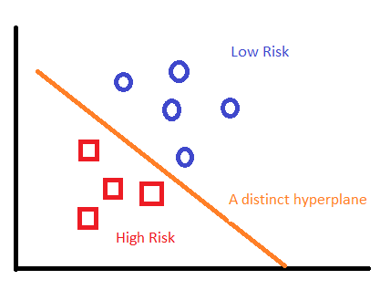

```r
knitr::include_graphics("svm.png")
```

There are some hyperparameters that can be tuned to get better performance. For example, there are many kernel types that can be used for SVM and C is a cost of constraint violation. SVM provides an access to adjust the weight of each label class so we can handle the imbalance data by adjusting class-weight parameters. We tried SVM with both Smote training sets, without Smote, apply class weights and apply both to compare the performance. After we find the best dataset, we try different kernel types and compare its performance. We also try different C to tune the hyperparameter.

```r
#baseline SVM
set.seed(7) #Set Seed for reproducibility
cluster <- makeCluster(detectCores()-1) #Use all CPU Cores available except 1, leave that for OS
registerDoParallel(cluster) #Tell R that the cluster of Cores can be used

#Write the code required
set.seed(7)
svm <- ksvm(STATUS ~ ., data = Train, kernel = "vanilladot")

saveRDS(svm, "svm.vanilladot.baseline.rds")

#Unlink the Cluster of CPU Cores
stopCluster(cluster)
```

```r
#Baseline RFDOT
set.seed(7) #Set Seed for reproducibility
cluster <- makeCluster(detectCores()-1) #Use all CPU Cores available except 1, leave that for OS
registerDoParallel(cluster) #Tell R that the cluster of Cores can be used

svmfit.baseline <- ksvm(STATUS ~ ., data = Train, kernel = "rbfdot", C = 10)

saveRDS(svmfit.baseline, "svmfit_rfdot.noSmote.rds")

#Unlink the Cluster of CPU Cores
stopCluster(cluster)
```

```r
# SVM RBFDOT WITH SMOTE
set.seed(7) #Set Seed for reproducibility
cluster <- makeCluster(detectCores()-1) #Use all CPU Cores available except 1, leave that for OS
registerDoParallel(cluster) #Tell R that the cluster of Cores can be used

svmfit <- ksvm(STATUS ~ ., data = Train_Smote, kernel = "rbfdot", C = 10)
saveRDS(svmfit, "svmfit.rfdot.smote.rds")

#Unlink the Cluster of CPU Cores
stopCluster(cluster)
```

```r
#SVM with weights
set.seed(7) #Set Seed for reproducibility
cluster <- makeCluster(detectCores()-1) #Use all CPU Cores available except 1, leave that for OS
registerDoParallel(cluster) #Tell R that the cluster of Cores can be used

#SVM With Cost
set.seed(7)
svm <- ksvm(STATUS ~ ., data = Train, kernel = "rbfdot", C = 10, class.weights= c("0" = 15, "1" = 25))

saveRDS(svmfit, "svmfit.rbfdot.cost.rds")

#Unlink the Cluster of CPU Cores
stopCluster(cluster)
```

```r
#SMOTED SVM with weights
set.seed(7) #Set Seed for reproducibility
cluster <- makeCluster(detectCores()-1) #Use all CPU Cores available except 1, leave that for OS
registerDoParallel(cluster) #Tell R that the cluster of Cores can be used

#SVM with Smote with COST

set.seed(7)
svmfit <- ksvm(STATUS ~ ., data = Train_Smote, kernel = "rbfdot", C = 10, class.weights= c("0" = 15, "1" = 25))

saveRDS(svmfit, "svmfit_smoted.rbfdot.cost.rds")
```

```r
set.seed(7) #Set Seed for reproducibility
cluster <- makeCluster(detectCores()-1) #Use all CPU Cores available except 1, leave that for OS
registerDoParallel(cluster) #Tell R that the cluster of Cores can be used

# SVM Vanilladot
set.seed(7)

svmfit <- ksvm(STATUS ~ ., data = Train_Smote, kernel = "vanilladot", C = 10)
prediction_result <- predict(svmfit, newdata = Test)

saveRDS(svmfit, "svmfit.smoted.vanilla.rds")


#Unlink the Cluster of CPU Cores
stopCluster(cluster)
```

```r
set.seed(7) #Set Seed for reproducibility
cluster <- makeCluster(detectCores()-1) #Use all CPU Cores available except 1, leave that for OS
registerDoParallel(cluster) #Tell R that the cluster of Cores can be used

# SVM polydot
set.seed(7)

svmfit <- ksvm(STATUS ~ ., data = Train_Smote, kernel = "polydot", C = 10)
prediction_result <- predict(svmfit, newdata = Test)

saveRDS(svmfit, "svmfit.smoted.polydot.rds")


#Unlink the Cluster of CPU Cores
stopCluster(cluster)
```

```r
set.seed(7) #Set Seed for reproducibility
cluster <- makeCluster(detectCores()-1) #Use all CPU Cores available except 1, leave that for OS
registerDoParallel(cluster) #Tell R that the cluster of Cores can be used

# SVM Tanhdot
set.seed(7)

svmfit <- ksvm(STATUS ~ ., data = Train_Smote, kernel = "tanhdot", C = 10)
prediction_result <- predict(svmfit, newdata = Test)

saveRDS(svmfit, "svmfit.smoted.tanh.rds")


#Unlink the Cluster of CPU Cores
stopCluster(cluster)
```

```r
set.seed(7) #Set Seed for reproducibility
cluster <- makeCluster(detectCores()-1) #Use all CPU Cores available except 1, leave that for OS
registerDoParallel(cluster) #Tell R that the cluster of Cores can be used

# SVM laplacedot
set.seed(7)

svmfit <- ksvm(STATUS ~ ., data = Train_Smote, kernel = "laplacedot", C = 10)
prediction_result <- predict(svmfit, newdata = Test)

saveRDS(svmfit, "svmfit.smoted.laplace.rds")


#Unlink the Cluster of CPU Cores
stopCluster(cluster)
```

```r
set.seed(7) #Set Seed for reproducibility
cluster <- makeCluster(detectCores()-1) #Use all CPU Cores available except 1, leave that for OS
registerDoParallel(cluster) #Tell R that the cluster of Cores can be used

# SVM besseldot
set.seed(7)

svmfit <- ksvm(STATUS ~ ., data = Train_Smote, kernel = "besseldot", C = 10)
prediction_result <- predict(svmfit, newdata = Test)

saveRDS(svmfit, "svmfit.smoted.besseldot.rds")



#Unlink the Cluster of CPU Cores
stopCluster(cluster)
```

##### 6.7 XGBOOST (eXtreme Garident Boosting Algorithm)

XGBOOST uses gradient boosting decision tree algorithm.In boosting models are added subsequently until no further improvements can be made. Errors made by previous model are corrected by new model. Gradient boosting uses gradient descent algorithm to minimize the loss when adding new models and new models are build to fit the pseudo residuals of previous model.

XGBOOST model was trained on both SMOTED data and original data.Scale_POS_WEIGHT was used to handle the imbalance class which is the ratio of negative class to positive class.

```r
set.seed(7)
#Baseline XGBOOST
#Preprocesing for XGBOOST
#Seprate target from data
data.labels <-as.data.frame(data$STATUS)
colnames(data.labels) <- "STATUS"


#subset of all numeric colmn
data.numeric <- data[,sapply(data,is.numeric)]

data.categorical <- data[,sapply(data,is.factor)]
data.categorical <- data.categorical[,-12] #removing target variable

#one hot matrix for factorial
categorical <- model.matrix(~.-1,data.categorical)
data.cmb <- cbind(data.numeric,categorical,data.labels)
data_matrix <- data.matrix(data.cmb)

#training and test set

inTrain <- createDataPartition(data.cmb$STATUS,p=0.8)[[1]]
Train.XGB <- data.cmb[inTrain,]
Test.XGB <- data.cmb[-inTrain,]
dim(Train.XGB)
dim(Test.XGB)
table(Train.XGB$STATUS)

X_train.XGB <- Train.XGB[,-48]
y_train.XGB <- as.data.frame(Train.XGB$STATUS)
colnames(y_train.XGB) <- "STATUS"

#testing data
X_test.XGB <- Test.XGB[,-48]
y_test.XGB <- as.data.frame(Test.XGB$STATUS)
colnames(y_test.XGB) <- "STATUS"

#test & train data to two separate Dmatrix objects
dtrain <- xgb.DMatrix(data=as.matrix(X_train.XGB),label=as.matrix(y_train.XGB))
dtest <- xgb.DMatrix(data=as.matrix(X_test.XGB),label=as.matrix(y_test.XGB))

negative_cases <- sum(y_train.XGB$STATUS=="0")
positive_Cases <- sum(y_train.XGB$STATUS=="1")
cluster <- makeCluster(detectCores()-1)

registerDoParallel(cluster)
xg.weights <- xgboost::xgboost(data=dtrain,
                 max_depth=3,nround=40,
                 early_stopping_rounds = 3,
                 objective="binary:logistic",scale_pos_weight=negative_cases/positive_Cases,
                 gamma = 1)
stopCluster(cluster)
saveRDS(xg.weights, "xgb.base.rds")
```

```r
# SMOTED XGBOOST
data.smoted <- SMOTE(STATUS~.,Train.XGB,perc.over=2100,perc.under =100)
table(data.smoted$STATUS)
set.seed(7)
X_train.XGB <- data.smoted[,-48]
y_train.XGB <- as.data.frame(data.smoted$STATUS)
colnames(y_train.XGB) <- "STATUS"

#testing data
X_test.XGB <- Test.XGB[,-48]
y_test.XGB <- as.data.frame(Test.XGB$STATUS)
colnames(y_test.XGB) <- "STATUS"

dtrain.smoted <- xgb.DMatrix(data=as.matrix(X_train.XGB),label=as.matrix(y_train.XGB))
dtest.smoted <- xgb.DMatrix(data=as.matrix(X_test.XGB),label=as.matrix(y_test.XGB))


# XGBOOST (eXtreme Garident Boosting Algorithm)

cluster <- makeCluster(detectCores()-1)
registerDoParallel(cluster)
xgb.smoted <- xgboost::xgboost(data=dtrain.smoted,
                 max_depth=3,nround=40,
                 early_stopping_rounds = 3,
                 objective="binary:logistic",scale_pos_weight=negative_cases/positive_Cases,
                 gamma = 1)
stopCluster(cluster)
saveRDS(xgb.smoted, "xgb.smoted.rds")
```

### 7.Classification Performance Evaluation

```r
#Logistic Regression
#Evaluation table
lg.model <- readRDS("lg.glm.rds")
lg.mode2 <- readRDS("lg.AIC.rds")
lg.mode3 <- readRDS("my.log.bag.rds")
lg.mode4 <- readRDS("lasso.rg.rds")
lg.mode5 <- readRDS("lasso.bagging.rds")
lg.mode6 <- readRDS("elastic.caret.rds")
lg.mode7 <- readRDS("bagging.elastic_caret.rds")

pred1 <- predict(lg.model, newdata = Test_Log,type='response')
pred1 <- as.factor(ifelse(pred1 < 0.5,0,1))
pred2 <- predict(lg.mode2, newdata = Test_Log,type='response')
pred2 <- as.factor(ifelse(pred2 < 0.5,0,1))
pred3 <- myBaggingPredict(bagmodel = lg.mode3, newdata = Test_Log,type="response")
pred3 <- as.factor(ifelse(pred3 < 0.5,0,1))
pred4 <- predict(lg.mode4, s = bestlam, newx = X_Test_Log, type="class")
pred5 <-  myBaggingPredict(bagmodel = lg.mode5, newdata = Test_Log, type= "response")
pred5 <- as.factor(ifelse(pred5 < 0.5,0,1))
pred6 <- predict(lg.mode6, newdata = Test_Log)
pred7 <- myBaggingPredict(bagmodel = lg.mode7, newdata = Test_Log, type= "response")
pred7 <- ifelse(pred7 < 0.5, 0, 1)

results(pred1,pred2,pred3,pred4,pred5,pred6,pred7,truth = Test$STATUS,model.names = c('Logistic Regression GLM','Logistic AIC Step','Bagged Logistic','Lasso Regression','Baggging Lasso Regression','Elastic NET','Bagging Elastic Net'))

#K Nearest Neighbour
knn.model1 <- readRDS("knn.baseline.rds")
knn.model2 <- readRDS("knn.smote.rds")

knn.pred1 <- predict(knn.model1, newdata = Test,type="prob")
knn.pred1 <- apply(knn.pred1,1,which.max)-1
knn.pred2 <- predict(knn.model2, newdata = Test_Log,type="prob")
knn.pred2 <- apply(knn.pred2,1,which.max)-1

results(knn.pred1,knn.pred2 ,truth = Test$STATUS,model.names = c("KNN Baseline","KNN SMOTED" ))

#Linear Discriminant Analysis
lda.model <- readRDS("LDA.NOSMOTE.rds")
lda.model1 <- readRDS("LDA.SMOTE.rds")
lda.model2 <- readRDS("LDA.Feature.Sel")
lda.model3 <- readRDS("LDA.SMOTE.BTSTRP")

pred.lda <- predict(lda.model, newdata = Test)
pred.lda1 <- predict(lda.model1, newdata = Test)
pred.lda2 <- predict(lda.model2, newdata = Test)
pred.lda3 <- predict(lda.model3, newdata = Test)

results(pred.lda,pred.lda1,pred.lda2,pred.lda3,truth = Test$STATUS,model.names = c('LDA','LDA with SMOTE','SMOTED LDA with Feature Selction','SMOTED LDA with Feature Selection & BootStrapping'))

#Decision Tree
dt.model1 <- readRDS("dt.base.rds")
dt.model2 <- readRDS("dt.smoted.rds")

dt.pred1 <- predict(dt.model1, newdata = Test , type="class")
dt.pred2 <- predict(dt.model2, newdata = Test , type="class")

results(dt.pred1,dt.pred2 ,truth = Test$STATUS,model.names = c("DT Baseline","DT SMOTED" ))

#Random Forest
rf.model1 <- readRDS("baseline.rf.rds")
rf.model2 <- readRDS("smoted.rf.rds")
rf.model3 <- readRDS("rf_smote_down.rds")
rf.model4 <- readRDS("model_rf_smote.rds")
rf.model5 <- readRDS("rf.ranger.rds")





pred.rf1 <- predict(rf.model1, newdata = Test)
pred.rf2 <- predict(rf.model2, newdata = Test)
pred.rf3 <- predict(rf.model3, newdata = Test)
pred.rf4 <- predict(rf.model4, newdata = Test)


rf.pred.prob <- predict(rf.model5, data = Test)$predictions #2d
rf.pred5 <- apply(rf.pred.prob, 1, which.max) - 1 #assigned class
rf.pred.prob <- apply(rf.pred.prob, 1, max) #max prob

results(pred.rf1,pred.rf2,pred.rf3,pred.rf4,rf.pred5,truth = Test$STATUS,model.names = c('Baseline Random Forest using Class Weights','SMOTED Random Forest','Upsampled SMOTED Random Forest','Downsampled SMOTED Random Forest','SMOTED Random Forest using wieghts'))

#Support Vector Machine
svm.model1 <- readRDS("svm.vanilladot.baseline.rds")
svm.model2 <- readRDS("svmfit_rfdot.noSmote.rds")
svm.model3 <- readRDS("svmfit.rfdot.smote.rds")
svm.model4 <- readRDS("svmfit.rbfdot.cost.rds")
svm.model5 <- readRDS("svmfit_smoted.rbfdot.cost.rds")
svm.model6 <- readRDS("svmfit.smoted.vanilla.rds")
svm.model7 <- readRDS("svmfit.smoted.polydot.rds")
svm.model8 <- readRDS("svmfit.smoted.tanh.rds")
svm.model9 <- readRDS("svmfit.smoted.laplace.rds")
svm.model10 <- readRDS("svmfit.smoted.besseldot.rds")


svm.pred1 <- predict(svm.model1,newdata=Test)
svm.pred2 <- predict(svm.model2,newdata=Test)
svm.pred3 <- predict(svm.model3,newdata=Test)
svm.pred4 <- predict(svm.model4,newdata=Test)
svm.pred5 <- predict(svm.model5,newdata=Test)
svm.pred6 <- predict(svm.model6,newdata=Test)
svm.pred7 <- predict(svm.model7,newdata=Test)
svm.pred8 <- predict(svm.model8,newdata=Test)
svm.pred9 <- predict(svm.model9,newdata=Test)
svm.pred10 <- predict(svm.model10,newdata=Test)


model_names= c("Baseline SVM (Vanilladot)","Baseline SVM (rbfdot)","SMOTE SVM (rbfdot)","Baseline SVM using Cost(rbfdot)","SMOTE SVM using Cost(rbfdot)","SMOTE SVM (Vanilladot)","SMOTE SVM (polydot)","SMOTE SVM (tanhdot)","SMOTE SVM (laplace)","SMOTE SVM (besseledot)")

results(svm.pred1,svm.pred2,svm.pred3,svm.pred4,svm.pred5,svm.pred6,svm.pred7,svm.pred8,svm.pred9,
        svm.pred10,truth = Test$STATUS,model.names =model_names)

# XGBoost
xgb.model1 <- readRDS("xgb.base.rds")
xgb.model2 <- readRDS("xgb.smoted.rds")

pred.xgb1 <- predict(xgb.model1, newdata = dtest)
pred.xgb1.decision <- ifelse(as.numeric(pred.xgb1 > 0.5),"1","0")

pred.xgb2 <- predict(xgb.model2, newdata = dtest.smoted)
pred.xgb2.decision <- ifelse(as.numeric(pred.xgb2 > 0.5),"1","0")

results(pred.xgb1.decision,pred.xgb2.decision,truth = y_test.XGB$STATUS,model.names = c('Baseline XGBOOST using weights','SMOTED XGBOOST'))
```

Given the significant class imbalance and the needed to identify high risk customers successfully, hence accuracy was not a suitable evaluation metric. Instead, we looked towards the F1-Score which was the harmonic mean between Recall and Precision. While the Recall evaluates what proportion of true positive classes were identified correctly, the Precision checks what proportion of predicted positive identifications were actually correct. We also used the Area under ROC curve that plots the Sensitivity vs Specificity as an evaluation metric to better present the ratio of True Positives to True Negatives.

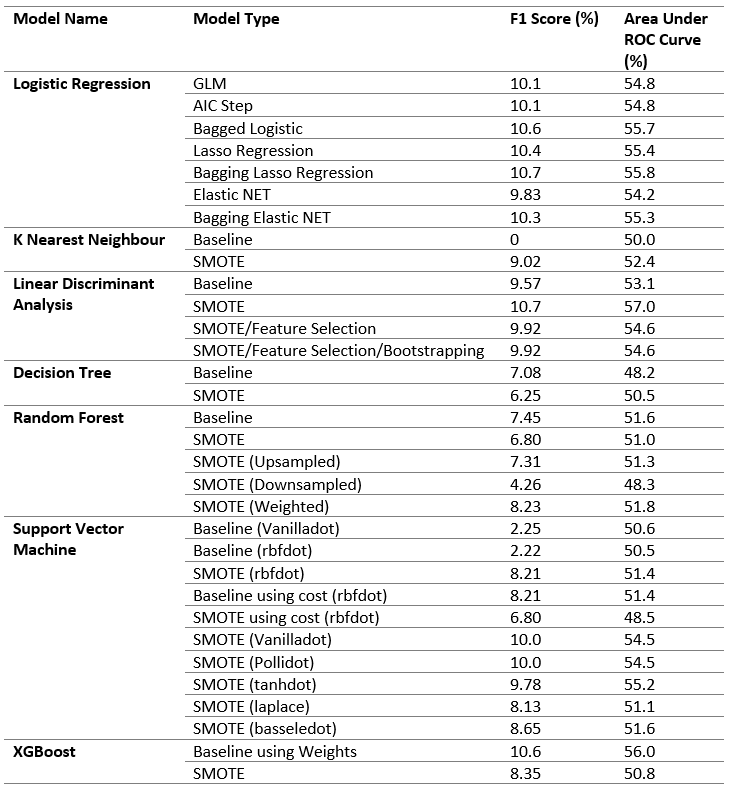

Performance of all models trained

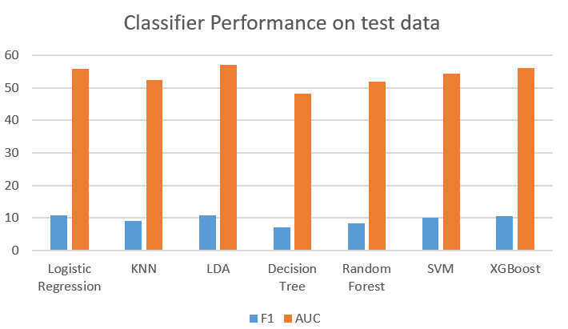

Model comparison

There is little variation that can be observed in F1 Scores once we plot the results for different models except for decision tree which seems to have a slightly lower score than the other classifiers. Decision Tree’s poor performance can also be verified by looking at the AUC Score where Decision tree has a significantly lesser score compared to the rest of the models.

Overall, it can be said that the best performing classifier is LDA followed by Logistic Regression and XGBoost.

### 8.Conclusion

After working through the dataset we found several problems with it: Most features are simplistic and therefore they might not be good predictors for the target. The features predictability is questionable (ex. we see many records having very little work experience as compared to their age). Age vs income total relation is not significant enough, not essentially reflecting a larger population trend. 68% of the dataset is duplicated which casts doubt over the genuity of the dataset.

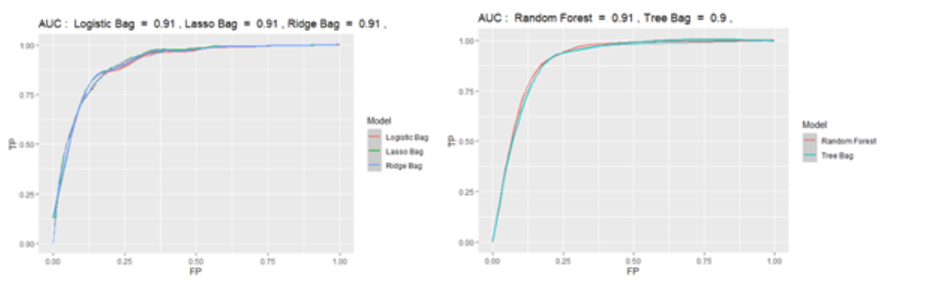

ROC Curve showing True positives and False positives on comparison dataset

This, from our perspective, shows that our models are able to train well and our initial attempts to address the imbalance in the data are vindicated. However our chosen dataset is the major cause behind the low F1 scores.

Despite the challenges, we were able to come up with the following conclusions about the dataset: Many of the risky customers happen to have cars and real estates. The data does not provide a bank balance, only income amount. Risky customers seem to come from most professions, across all income ranges.